# STAT 385 Homework Assignment 01

### 3. With the `data(iris)` dataset in R, do the following calculations:

1. the sum of the 25th and 26th versicolor iris’s sepal lengths divided by 2

```r
data(iris)
sum = (iris[75,1] + iris[76,1])/2
print(sum)
```

```
## [1] 6.5
```

2. the sum of all petal lengths among all species of iris that are between 0 cm and 3 cm

```r
#print(iris)
petal_length = iris[,3]
sum = sum(petal_length[petal_length >=0 & petal_length <= 3])
print(sum)
```

```
## [1] 76.1
```

3. assuming `x` equals the sepal length of the 10th virginica iris, then $4\cdot x/2^3$

```r
x = iris[110,1]
result = 4*x/(2^3)
print(result)
```

```
## [1] 3.6
```

4. assuming `x` equals the sum of all setosa sepal widths, then $4\cdot(x/2)^3$.

```r
x = sum(iris[1:50,2])
result = 4*(x/2)^3
print(result)
```

```
## [1] 2517691
```

### 4. Using the Instructor Notes from Week 03, address the following:

1. run the code that appears in slide 20 of the intro_slides.pdf slide deck.

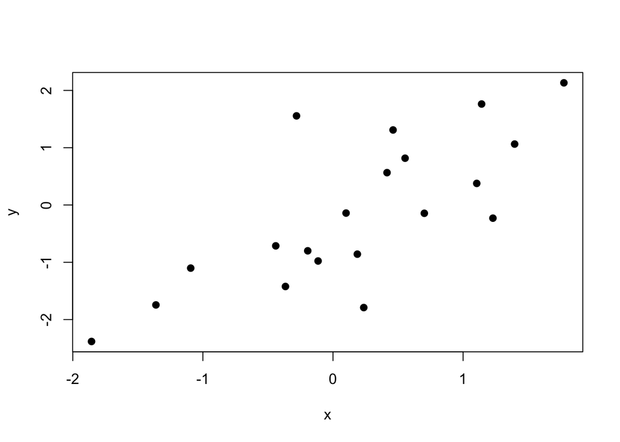

```r
set.seed(13) ## set the random seed
x <- rnorm(n = 20) ## generate predictor variable
y <- rnorm(n = 20, mean = x) ## generate response variable
plot(y ~ x, pch = 19) ## plot (x,y) pairs
```

2. change the seed number in the `set.seed()` command from 13 to 14. Then, re-run the code in part **a**.

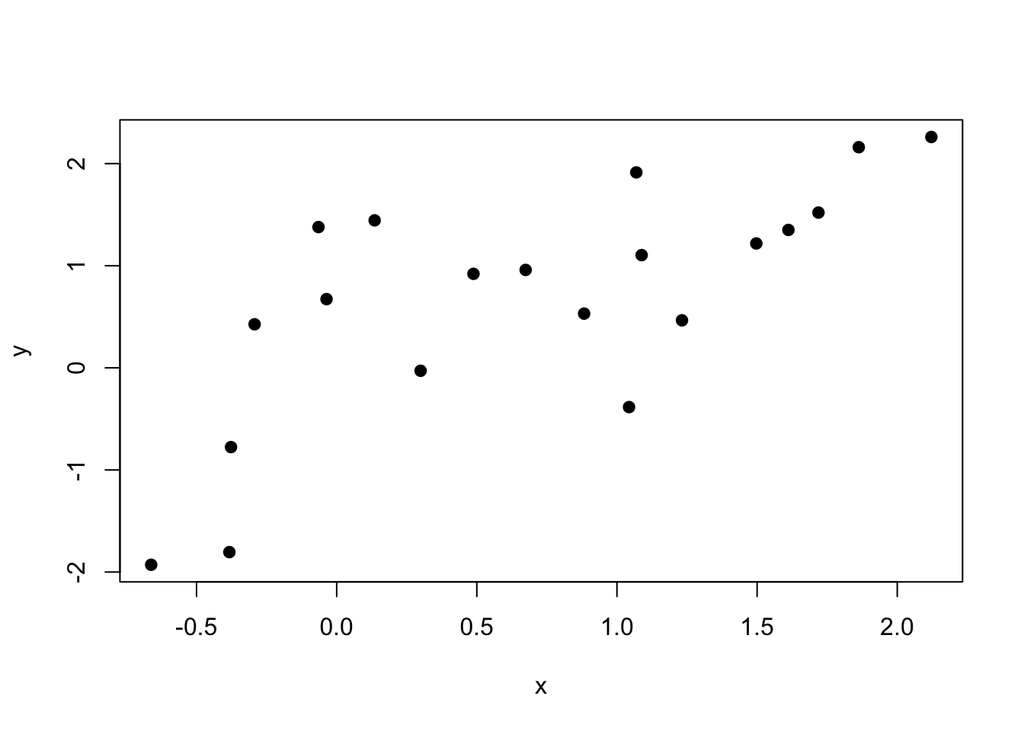

```r
set.seed(14) ## set the random seed
x <- rnorm(n = 20) ## generate predictor variable
y <- rnorm(n = 20, mean = x) ## generate response variable
plot(y ~ x, pch = 19) ## plot (x,y) pairs
```

3. Is there a difference between the results of parts **a** and **b**? If so, describe some of the obvious differences.

4. Why is it important to set the random seed at the beginning of a simulation?